Skip to main content

# Are EU regions converging?

Project C: income and employment gaps between EU regions, 2000-2024

Author

Project C Group 7

## Our question

> Between 2000 and 2024, did EU27 NUTS2 regions converge in GDP per head (PPS) and employment rate (ages 20-64), and which groups of regions did not follow the pattern?

## Data

### GDP per head

GDP per head comes from Eurostat table `nama_10r_2gdp`, in purchasing power standards (PPS, `PPS_EU27_2020_HAB`), for EU27 NUTS2 regions, 2000-2024. Extra-regio territories and non-EU countries were removed, which leaves 244 regions. PPS adjusts for price differences between countries, so it compares what incomes can buy and not only their size in euro. The 2024 values are provisional.

### Employment rate

Employment rates come from Eurostat table `lfst_r_lfe2emprt`: the share of people who are in work, both sexes, in percent, for EU27 NUTS2 regions, 2000-2024. The main measure covers ages 20-64, the age group of the EU employment target. As a robustness check for Question 2 we repeat the analysis for ages 15-64 (`Y15-64`), taken from the same raw file with the same filters, so the two measures differ only in the age group. Extra-regio territories and non-EU countries were removed, and Slovenian and Dutch regions that were only renamed were joined to their new codes. Regions that were split or merged are not recoded. This is why the employment file has more region codes than the GDP file: the extra codes are old regions (HR04, HU10, IE01, IE02, LT00, PT16-PT18). Question 2 uses the regions that have an employment rate in both 2000 and 2024. Some of these values carry Eurostat flags, mostly for a break in the series or a different definition in 2024. The numbers below come from the cleaned files:

```python
import pandas as pd

emp_chk = pd.read_csv("data/clean/emp.csv")
gdp_chk = pd.read_csv("data/clean/gdp.csv")

def both_years(df, col):
    w = df[df["year"].isin([2000, 2024])].pivot(index="geo", columns="year", values=col)
    return w.dropna(subset=[2000, 2024]).index

emp_both = both_years(emp_chk, "emp_rate")
gdp_both = both_years(gdp_chk, "gdp_pps")
flag_2024 = emp_chk[(emp_chk["year"] == 2024) & emp_chk["geo"].isin(emp_both)]["emp_rate_flag"].fillna("")

print(f"Region codes: employment file {emp_chk['geo'].nunique()}, GDP file {gdp_chk['geo'].nunique()}")
print(f"In the employment file but not in the GDP file: {sorted(set(emp_chk['geo']) - set(gdp_chk['geo']))}")
print(f"Regions with an employment rate in 2000 and 2024: {len(emp_both)} (also with GDP in both years: {len(emp_both.intersection(gdp_both))})")
print(f"2024 values flagged as break in series (b) or different definition (d): {flag_2024.str.contains('[bd]').sum()} of {len(flag_2024)}")
```

```
Region codes: employment file 252, GDP file 244
In the employment file but not in the GDP file: ['HR04', 'HU10', 'IE01', 'IE02', 'LT00', 'PT16', 'PT17', 'PT18']
Regions with an employment rate in 2000 and 2024: 199 (also with GDP in both years: 188)
2024 values flagged as break in series (b) or different definition (d): 42 of 199
```

### Sector gross value added

The sector structure comes from Eurostat table `nama_10r_3gva`: gross value added (GVA) by industry, in million euro at current prices (`CP_MEUR`), 2000-2024. Industries follow the NACE classification (`nace_r2`). The raw file holds NUTS3 regions, but it also holds Eurostat’s own values for the NUTS2 regions. We added the NUTS3 values up to NUTS2 as a check (amounts can be added up; shares and rates cannot). Where all NUTS3 parts have a value, the sum is within 0.1% of the NUTS2 value in almost every case. Where some parts are missing the sum is too small, and in no case could the sum fill a NUTS2 value that Eurostat leaves empty. We therefore use Eurostat’s NUTS2 values, and the cleaned file `gva.csv` contains exactly these values (Table 1).

```python
import numpy as np
import pandas as pd

# 1. Raw Eurostat file: wide, one column per year; a value can carry a flag, for example "1221.7 p"
sec_raw = pd.read_csv("data/raw_data/estat_nama_10r_3gva.tsv", sep="\t", dtype=str)
sec_raw.columns = [c.strip() for c in sec_raw.columns]
first = sec_raw.columns[0]
dims = first.split("\\")[0].split(",")                       # freq, unit, nace_r2, geo
sec_raw[dims] = sec_raw[first].str.split(",", expand=True)
sec_raw = sec_raw[sec_raw["unit"] == "CP_MEUR"].drop(columns=[first])    # million euro, current prices

# 2. One row per region, sector and year; split each cell into its value and its flag
sec_long = sec_raw.melt(id_vars=dims, var_name="year", value_name="cell")
sec_long["year"] = sec_long["year"].str.strip().astype(int)
sec_long["cell"] = sec_long["cell"].str.strip()
sec_long["value"] = pd.to_numeric(sec_long["cell"].str.extract(r"^([\d.]+)")[0], errors="coerce")
sec_long["flag"] = sec_long["cell"].str.extract(r"^[\d.]+\s*([a-z]+)$")[0]

# 3. Our regions are the 244 EU27 NUTS2 regions of the cleaned file; we keep the six sectors and the total
sec_regions = set(pd.read_csv("data/clean/gva_sector.csv")["geo"])
six = ["A", "B-E", "F", "G-J", "K-N", "O-U"]
sec_long = sec_long[sec_long["nace_r2"].isin(six + ["TOTAL"])]
official = sec_long[sec_long["geo"].isin(sec_regions)].rename(columns={"value": "official"})
nuts3 = sec_long[(sec_long["geo"].str.len() == 5) & sec_long["geo"].str[:4].isin(sec_regions)].copy()
nuts3["nuts2"] = nuts3["geo"].str[:4]                # the NUTS2 parent is the first four characters

# 4. Sum the NUTS3 values to NUTS2 (these are amounts, so summing is valid) and count the parts present
summed = nuts3.groupby(["nace_r2", "nuts2", "year"]).agg(
    sum_nuts3=("value", "sum"), parts_present=("value", "count"), parts_total=("geo", "nunique")
).reset_index().rename(columns={"nuts2": "geo"})
chk = official[["nace_r2", "geo", "year", "official"]].merge(summed, on=["nace_r2", "geo", "year"], how="left")
chk["complete"] = chk["parts_present"] == chk["parts_total"]       # all NUTS3 parts have a value
chk["ratio"] = chk["sum_nuts3"] / chk["official"]

has = chk[chk["official"].notna()]
done = has[has["complete"]]
part = has[~has["complete"] & (has["parts_total"] > 0)]
gone = chk[chk["official"].isna()]
check_tbl = pd.DataFrame({"cells": {
    "NUTS2 values published by Eurostat (six sectors and total)": len(has),
    "... with all NUTS3 parts present": len(done),
    "... of these: NUTS3 sum within 0.1% of the NUTS2 value": int(((done["ratio"] - 1).abs() <= 0.001).sum()),
    "... of these: largest difference (%)": round(float((done["ratio"] - 1).abs().max() * 100), 2),
    "... with some NUTS3 parts missing": len(part),
    "... of these: no NUTS3 value present at all": int((part["parts_present"] == 0).sum()),
    "NUTS2 values missing at Eurostat": len(gone),
    "... that the NUTS3 sum could fill (all parts present)": int((gone["complete"] & (gone["parts_total"] > 0)).sum()),
}})
check_tbl
```

Table 1: Check of the sector GVA table: Eurostat NUTS2 values against the sum of their NUTS3 parts

|  | cells |
| --- | --- |
| NUTS2 values published by Eurostat (six sectors and total) | 42067.00 |
| ... with all NUTS3 parts present | 41536.00 |
| ... of these: NUTS3 sum within 0.1% of the NUTS2 value | 41403.00 |
| ... of these: largest difference (%) | 1.67 |
| ... with some NUTS3 parts missing | 531.00 |
| ... of these: no NUTS3 value present at all | 520.00 |
| NUTS2 values missing at Eurostat | 633.00 |
| ... that the NUTS3 sum could fill (all parts present) | 0.00 |

We keep six sectors that do not overlap: agriculture, forestry and fishing (A); industry, including energy and manufacturing (B-E); construction (F); trade, transport, accommodation and food, and information and communication (G-J); finance and insurance, real estate, professional and administrative services (K-N); and public administration, education, health, arts and other services (O-U). Codes such as C (manufacturing) or G-I are parts of these sectors, and we do not use them, because they would count the same value twice. The share of a sector is its GVA divided by the total GVA of the region, in percent. The six sectors add up to the total within 0.04%, so the shares add up to 100%.

```python
# Is the cleaned file the same as the Eurostat NUTS2 values?
team_gva = pd.read_csv("data/clean/gva.csv")
team_gva = team_gva[team_gva["sector"].isin(six + ["TOTAL"])].rename(columns={"sector": "nace_r2"})
both = team_gva.merge(has[["nace_r2", "geo", "year", "official"]], on=["nace_r2", "geo", "year"], how="outer")
differ = both["gva_meur"].sub(both["official"]).abs().gt(0.5) | (both["gva_meur"].isna() != both["official"].isna())
print(f"Cells in the cleaned file: {both['gva_meur'].notna().sum()}; Eurostat NUTS2 cells: {both['official'].notna().sum()}; cells that differ: {int(differ.sum())}")

# The six sectors add up to the total (shares are therefore close to 100%)
tot = team_gva[team_gva["nace_r2"] == "TOTAL"].set_index(["geo", "year"])["gva_meur"]
six_sum = team_gva[team_gva["nace_r2"] != "TOTAL"].groupby(["geo", "year"])["gva_meur"].sum()
gap = ((six_sum / tot - 1) * 100).dropna()
print(f"Sum of the six sectors against the total, difference in %: min {gap.min():.3f}, median {gap.median():.3f}, max {gap.max():.3f}")
```

```
Cells in the cleaned file: 42067; Eurostat NUTS2 cells: 42067; cells that differ: 0
Sum of the six sectors against the total, difference in %: min -0.020, median 0.000, max 0.036
```

Coverage is not complete. Belgium has no sector values before 2003, and Germany, the Netherlands and Poland have none for 2024. The values for 2023 and 2024 are provisional or estimated, and the 2009 values of some regions carry a break flag (Table 2, Table 3).

```python
sec_clean = pd.read_csv("data/clean/gva_sector.csv")
fl = team_gva[team_gva["nace_r2"] != "TOTAL"]
sec_cov = pd.DataFrame({"regions with sector values": sec_clean.groupby("year")["geo"].nunique()})
sec_cov["cells with flag p or e (%)"] = fl["gva_meur_flag"].isin(["p", "e"]).groupby(fl["year"]).mean().mul(100).round(0)
sec_cov["cells with flag b (break)"] = fl["gva_meur_flag"].eq("b").groupby(fl["year"]).sum()
sec_cov = sec_cov.loc[[2000, 2003, 2009, 2019, 2023, 2024]]
sec_cov.index.name = "Year"
sec_cov
```

Table 2: Regions with all six sector values and Eurostat flags on the six sectors, selected years

| Year | regions with sector values | cells with flag p or e (%) | cells with flag b (break) |
| --- | --- | --- | --- |
| 2000 | 233 | 0.0 | 0 |
| 2003 | 244 | 0.0 | 0 |
| 2009 | 244 | 0.0 | 66 |
| 2019 | 244 | 0.0 | 0 |
| 2023 | 244 | 40.0 | 0 |
| 2024 | 177 | 60.0 | 0 |

```python
sec_span = sec_clean.groupby("geo")["year"].agg(first_year="min", last_year="max", years="nunique")
sec_span["country"] = sec_span.index.str[:2]
sec_gaps = sec_span[sec_span["years"] < 25].groupby("country").agg(
    regions=("years", "size"), first_year=("first_year", "min"), last_year=("last_year", "max"), years_with_data=("years", "min"))
sec_gaps.index = [{"BE": "Belgium", "DE": "Germany", "NL": "Netherlands", "PL": "Poland"}.get(c, c) for c in sec_gaps.index]
sec_gaps
```

Table 3: Regions without sector values in every year 2000-2024, by country

|  | regions | first_year | last_year | years_with_data |
| --- | --- | --- | --- | --- |
| Belgium | 11 | 2003 | 2024 | 22 |
| Germany | 38 | 2000 | 2023 | 24 |
| Netherlands | 12 | 2000 | 2023 | 24 |
| Poland | 17 | 2000 | 2023 | 24 |

All 244 region codes of the sector table are the same as in the GDP table, so the two tables join without recoding. How many regions can be used together is shown below:

```python
# Joined result: do the sector table and the GDP and employment tables describe the same regions?
j_gdp = pd.read_csv("data/clean/gdp.csv")
j_emp = pd.read_csv("data/clean/emp.csv")
def has_both(df, col):
    w = df[df["year"].isin([2000, 2024])].pivot(index="geo", columns="year", values=col)
    return set(w.dropna(subset=[2000, 2024]).index)
j_sec00 = set(sec_clean[sec_clean["year"] == 2000]["geo"])
j_g, j_e = has_both(j_gdp, "gdp_pps"), has_both(j_emp, "emp_rate")
print(f"Region codes: sector table {sec_clean['geo'].nunique()}, GDP table {j_gdp['geo'].nunique()}; only in one of them: {sorted(set(sec_clean['geo']) ^ set(j_gdp['geo']))}")
print(f"Sector shares in 2000: {len(j_sec00)} regions (missing: {sorted(set(sec_clean['geo']) - j_sec00)[:3]} ... all of Belgium)")
print(f"Sector shares in 2000 and GDP in 2000 and 2024: {len(j_sec00 & j_g)}")
print(f"... and also an employment rate in 2000 and 2024: {len(j_sec00 & j_g & j_e)}")
print(f"Regions with GDP and employment in both years but no 2000 sector shares: {sorted((j_g & j_e) - j_sec00)}")
no_emp = sorted((j_sec00 & j_g) - j_e)
emp_2000 = set(j_emp[(j_emp["year"] == 2000) & j_emp["emp_rate"].notna()]["geo"])
print(f"Regions with sector shares and GDP but no employment rate in both years: {len(no_emp)}; of these without an employment value for 2000: {sum(r not in emp_2000 for r in no_emp)}")
print("... by country:", pd.Series([r[:2] for r in no_emp]).value_counts().to_dict())
```

```
Region codes: sector table 244, GDP table 244; only in one of them: []
Sector shares in 2000: 233 regions (missing: ['BE10', 'BE21', 'BE22'] ... all of Belgium)
Sector shares in 2000 and GDP in 2000 and 2024: 232
... and also an employment rate in 2000 and 2024: 188
Regions with GDP and employment in both years but no 2000 sector shares: []
Regions with sector shares and GDP but no employment rate in both years: 44; of these without an employment value for 2000: 44
... by country: {'BG': 5, 'DE': 5, 'DK': 5, 'PT': 5, 'FR': 4, 'HR': 4, 'FI': 3, 'IE': 3, 'HU': 2, 'IT': 2, 'LT': 2, 'PL': 2, 'SI': 2}
```

### Youth unemployment

Youth unemployment rates come from Eurostat table `lfst_r_lfu3rt`: the share of the labour force that is unemployed, in percent, both sexes, all education levels, for EU27 NUTS2 regions, 2000-2024. The main measure covers ages 15-24, the standard headline definition (decision 4). As a check we repeat the analysis for ages 15-29 (`Y15-29`). Both files are made from the same raw file with the same filters and the same region rules (script `clean_data.py`), so they differ only in the age group. Extra-regio territories and non-EU countries were removed, and Slovenian and Dutch regions that were only renamed were joined to their new codes. Many regions have no value in some years, and some values carry Eurostat’s `u` flag for low reliability (Table 4).

```python
import numpy as np
import pandas as pd
import matplotlib.pyplot as plt
from scipy.stats import linregress

y24 = pd.read_csv("data/clean/youth_15_24.csv")
y29 = pd.read_csv("data/clean/youth_15_29.csv")

def wide(df, col):
    return df.pivot(index="geo", columns="year", values=col)

w24 = wide(y24, "youth_unemp")
w29 = wide(y29, "youth_unemp")

def coverage(df, w, label):
    flagged = df["youth_unemp_flag"].fillna("").str.contains("u").mean() * 100
    return {
        "age group": label,
        "regions (any year)": w.shape[0],
        "regions with a value in 2000": int(w[2000].notna().sum()),
        "regions with a value in 2024": int(w[2024].notna().sum()),
        "regions with 2000 AND 2024": w.dropna(subset=[2000, 2024]).shape[0],
        "regions with all 25 years": w.dropna().shape[0],
        "values flagged u (%)": round(flagged),
    }

cov = pd.DataFrame([coverage(y24, w24, "15-24"), coverage(y29, w29, "15-29")]).set_index("age group").T
cov
```

Table 4: Coverage of the youth unemployment files, ages 15-24 and 15-29

| age group | 15-24 | 15-29 |
| --- | --- | --- |
| regions (any year) | 248 | 251 |
| regions with a value in 2000 | 166 | 182 |
| regions with a value in 2024 | 180 | 207 |
| regions with 2000 AND 2024 | 123 | 151 |
| regions with all 25 years | 90 | 122 |
| values flagged u (%) | 20 | 11 |

Only 123 of the 248 regions (15-24) and 151 of the 251 regions (15-29) have a value in both 2000 and 2024, therefore the catching-up test below covers about half of the regions.

## Question 1: Is the gap between regions narrowing?

### Measure

We measure the gap with **sigma convergence**: for each year, the standard deviation of the natural logarithm of GDP per head across regions. A smaller value means regions are closer together. Using logarithms means the measure reflects percentage differences between regions, not differences in euro. We also compute the coefficient of variation (standard deviation divided by the mean), which is based on levels instead of logs.

### Data and sample

```python
import matplotlib.pyplot as plt
import numpy as np
import pandas as pd

path = "data/clean/gdp.csv"          # columns: geo, year, gdp_pc (PPS per head)
gdp = pd.read_csv("data/clean/gdp.csv")
gdp["log_gdp"] = np.log(gdp["gdp_pps"])

n_years = gdp.groupby("geo")["year"].nunique()
balanced = n_years[n_years == 25].index          # regions with a value in every year 2000-2024

def spread(df):
    g = df.groupby("year")
    return pd.DataFrame({
        "regions": g["geo"].nunique(),
        "sigma_log": g["log_gdp"].std(),                   # std. deviation of log GDP per head
        "cv": g["gdp_pps"].std() / g["gdp_pps"].mean(),    # coefficient of variation
    })

A = spread(gdp)                                           # A: every region with a value that year
B = spread(gdp[gdp["geo"].isin(balanced)])                # B: only regions with all 25 years
C = spread(gdp[~gdp["geo"].str.startswith("RO")])         # C: sample A without Romania
```

The GDP file has 244 regions, but not all of them have a value in every year. Table 5 lists the regions with gaps.

```python
span = gdp.groupby("geo")["year"].agg(first_year="min", last_year="max", years_with_data="count")
span["country"] = span.index.str[:2]
gaps = span[span["years_with_data"] < 25]
names = {"BE": "Belgium", "FR": "France", "RO": "Romania"}
gaps_by_country = gaps.groupby("country").agg(
    regions=("first_year", "size"),
    first_year_with_data=("first_year", "min"),
    fewest_years_with_data=("years_with_data", "min"))
gaps_by_country.index = [names.get(c, c) for c in gaps_by_country.index]
gaps_by_country
```

Table 5: Regions without a GDP value in every year 2000-2024, by country

|  | regions | first_year_with_data | fewest_years_with_data |
| --- | --- | --- | --- |
| Belgium | 11 | 2003 | 22 |
| France | 1 | 2014 | 11 |
| Romania | 8 | 2000 | 15 |

Because of these gaps we use three samples:

- **Sample A:** every region that has a value in a given year. The number of regions changes from year to year.
- **Sample B:** only the 224 regions that have a value in every year. This sample is the same in every year.
- **Sample C:** sample A without Romania, to isolate the effect of Romania’s gap.

### Results

```python
years = [2000, 2001, 2002, 2003, 2008, 2011, 2012, 2019, 2024]
table = pd.DataFrame({
    "A regions": A.loc[years, "regions"], "A spread": A.loc[years, "sigma_log"],
    "C regions": C.loc[years, "regions"], "C spread": C.loc[years, "sigma_log"],
    "B regions": B.loc[years, "regions"], "B spread": B.loc[years, "sigma_log"],
}).round(3)
table.index.name = "Year"
table
```

Table 6: Number of regions and spread of log GDP per head in selected years (A: all available, C: A without Romania, B: regions with every year)

| Year | A regions | A spread | C regions | C spread | B regions | B spread |
| --- | --- | --- | --- | --- | --- | --- |
| 2000 | 232 | 0.513 | 224 | 0.465 | 224 | 0.465 |
| 2001 | 232 | 0.498 | 224 | 0.453 | 224 | 0.453 |
| 2002 | 224 | 0.441 | 224 | 0.441 | 224 | 0.441 |
| 2003 | 235 | 0.426 | 235 | 0.426 | 224 | 0.427 |
| 2008 | 235 | 0.390 | 235 | 0.390 | 224 | 0.393 |
| 2011 | 235 | 0.386 | 235 | 0.386 | 224 | 0.388 |
| 2012 | 243 | 0.397 | 235 | 0.387 | 224 | 0.388 |
| 2019 | 244 | 0.378 | 236 | 0.374 | 224 | 0.366 |
| 2024 | 244 | 0.355 | 236 | 0.352 | 224 | 0.344 |

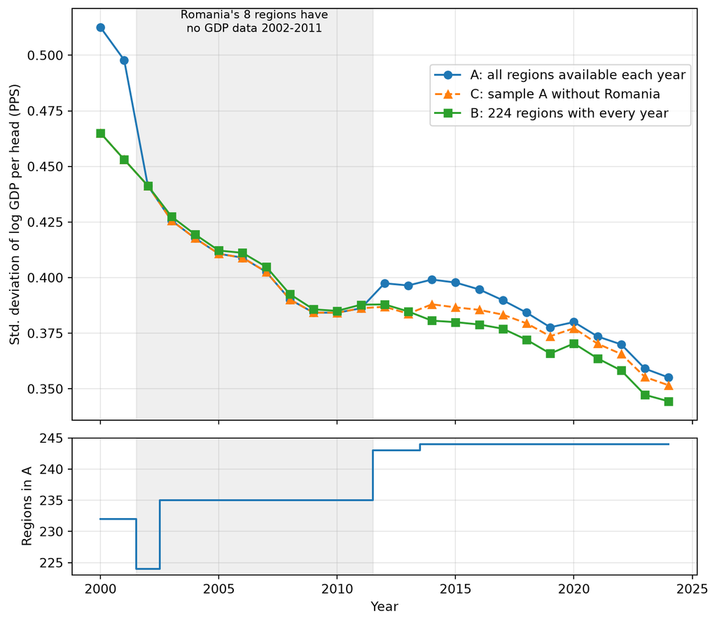

Figure 1: Spread of GDP per head across EU regions, 2000-2024. The lower panel shows the number of regions in sample A; the grey band marks the years in which Romania’s 8 regions have no GDP data.

```python
fig, (ax1, ax2) = plt.subplots(2, 1, figsize=(8, 7), sharex=True,
                               gridspec_kw={"height_ratios": [3, 1]})
ax1.plot(A.index, A["sigma_log"], "o-", label="A: all regions available each year")
ax1.plot(C.index, C["sigma_log"], "^--", label="C: sample A without Romania")
ax1.plot(B.index, B["sigma_log"], "s-", label=f"B: {len(balanced)} regions with every year")
ax1.axvspan(2001.5, 2011.5, color="grey", alpha=0.12)
ax1.text(2006.5, ax1.get_ylim()[1], "Romania's 8 regions have\nno GDP data 2002-2011",
         ha="center", va="top", fontsize=9)
ax1.set_ylabel("Std. deviation of log GDP per head (PPS)")
ax1.legend(loc="upper right", bbox_to_anchor=(1, 0.88))
ax1.grid(alpha=0.3)
ax2.step(A.index, A["regions"], where="mid")
ax2.axvspan(2001.5, 2011.5, color="grey", alpha=0.12)
ax2.set_ylabel("Regions in A")
ax2.set_xlabel("Year")
ax2.grid(alpha=0.3)
fig.tight_layout()
plt.show()
```

The numbers quoted in the text below come from this code, so they can be checked:

```python
def pct(S, col): return (S.loc[2024, col] / S.loc[2000, col] - 1) * 100

print(f"Change in spread 2000-2024 (log):  A {pct(A,'sigma_log'):+.1f}%   B {pct(B,'sigma_log'):+.1f}%")
print(f"Change in coefficient of variation: A {pct(A,'cv'):+.1f}%   B {pct(B,'cv'):+.1f}%")

total_fall = B.loc[2000, "sigma_log"] - B.loc[2024, "sigma_log"]
fall_2008 = B.loc[2000, "sigma_log"] - B.loc[2008, "sigma_log"]
print(f"\nSample B: spread {B.loc[2000,'sigma_log']:.3f} (2000), {B.loc[2008,'sigma_log']:.3f} (2008), {B.loc[2024,'sigma_log']:.3f} (2024)")
print(f"Total fall {total_fall:.3f}; fall by 2008 {fall_2008:.3f} = {fall_2008/total_fall*100:.0f}% of the total")
print(f"Pace per year: 2000-2008 {fall_2008/8:.4f} | 2008-2024 {(B.loc[2008,'sigma_log']-B.loc[2024,'sigma_log'])/16:.4f}")
print(f"Change 2019 to 2020 in B: {B.loc[2020,'sigma_log']-B.loc[2019,'sigma_log']:+.3f}")

drop_A = A.loc[2000, "sigma_log"] - A.loc[2002, "sigma_log"]
drop_C = C.loc[2000, "sigma_log"] - C.loc[2002, "sigma_log"]
print(f"\nDrop 2000 to 2002: A {drop_A:.3f}, C (no Romania) {drop_C:.3f}; share caused by Romania {(drop_A-drop_C)/drop_A*100:.0f}%")
print(f"Change 2011 to 2012: A {A.loc[2012,'sigma_log']-A.loc[2011,'sigma_log']:+.3f}, C {C.loc[2012,'sigma_log']-C.loc[2011,'sigma_log']:+.3f}")
print(f"Romania adds to the spread: 2000 {A.loc[2000,'sigma_log']-C.loc[2000,'sigma_log']:.3f}, 2024 {A.loc[2024,'sigma_log']-C.loc[2024,'sigma_log']:.3f}")

for y in (2001, 2024):
    d = gdp[gdp["year"] == y].copy()
    d["rank"] = d["gdp_pps"].rank(method="first")          # 1 = poorest
    ro = d[d["geo"].str.startswith("RO")]
    print(f"\n{y}: Romanian regions among the 12 poorest: {(ro['rank'] <= 12).sum()} of {len(ro)}; "
          f"median GDP per head Romania {ro['gdp_pps'].median():,.0f} vs all regions {d['gdp_pps'].median():,.0f} "
          f"({ro['gdp_pps'].median()/d['gdp_pps'].median()*100:.0f}%)")
```

```
Change in spread 2000-2024 (log):  A -30.7%   B -25.9%
Change in coefficient of variation: A -13.0%   B -9.8%

Sample B: spread 0.465 (2000), 0.393 (2008), 0.344 (2024)
Total fall 0.121; fall by 2008 0.072 = 60% of the total
Pace per year: 2000-2008 0.0091 | 2008-2024 0.0030
Change 2019 to 2020 in B: +0.005

Drop 2000 to 2002: A 0.071, C (no Romania) 0.024; share caused by Romania 67%
Change 2011 to 2012: A +0.011, C +0.001
Romania adds to the spread: 2000 0.048, 2024 0.004

2001: Romanian regions among the 12 poorest: 7 of 8; median GDP per head Romania 4,850 vs all regions 18,300 (27%)

2024: Romanian regions among the 12 poorest: 1 of 8; median GDP per head Romania 26,150 vs all regions 34,650 (75%)
```

### Interpretation

Both samples show a fall in the spread of GDP per head (PPS) across EU regions between 2000 and 2024: by about 31% in sample A and 26% in sample B (Table 6, Figure 1). Regions therefore became more similar in income per head. The coefficient of variation also falls, but by less (about 13% in A and 10% in B).

Most of the fall came before 2008. In sample B the spread fell from 0.465 to 0.393 by 2008, about 60% of the total fall of 0.121, or roughly 0.009 per year. From 2008 to 2024 it kept falling, but at about a third of that pace (roughly 0.003 per year). There was a small rise in 2020, which did not change the downward trend, and around 2012 sample B was almost unchanged.

Sample A should be read with care. Eurostat has no GDP values for Romania’s 8 regions in 2002-2011 (Table 5), so sample A has 232 regions in 2000, 224 in 2002 and 243 in 2012 (Figure 1, lower panel). Sample C (A without Romania) shows the effect: about two thirds of the drop in A between 2000 and 2002 (0.047 of 0.071) comes from the Romanian regions leaving the sample, and the rise in 2012 appears only in A. Including Romania adds 0.048 to the spread in 2000 but only 0.004 in 2024, which is why the fall looks larger in A (31%) than in B (26%).

The Romanian regions started far below the rest: in 2001, 7 of the 8 were among the 12 poorest regions in the data, and their median GDP per head was about 27% of the median of all regions. By 2024 it was about 75%. Sample B is the more consistent picture, because it uses the same 224 regions in every year, but it leaves out Romania, Belgium and one French region, which have gaps. Because Romania’s regions started so far below the rest and then caught up, B may understate how much narrowing took place.

Overall, income per head became more similar across EU regions between 2000 and 2024, with most of the narrowing before 2008. This analysis does not show why this happened, for example whether EU funding played a role.

### Robustness checks

We repeated the analysis with three changes: without the largest city regions (GDP per head is inflated where many commuters work), starting in 2003 so that Belgium is included, and using euro per head instead of PPS.

```python
cities = ["AT13", "BE10", "DE60", "DE30", "CZ01", "SK01", "FR10", "HU11", "PL91", "RO32"]
cities = [c for c in cities if c in set(gdp["geo"])]
D = spread(gdp[~gdp["geo"].isin(cities)])
E = spread(gdp[gdp["geo"].isin(balanced) & ~gdp["geo"].isin(cities)])

Spread03 = spread(gdp[gdp["year"] >= 2003])
g03 = gdp[gdp["year"] >= 2003]
full03 = g03.groupby("geo")["year"].nunique()
full03 = full03[full03 == 22].index
Cx = spread(g03[g03["geo"].isin(full03)])

def chg(S, y0, y1): return (S.loc[y1, "sigma_log"] / S.loc[y0, "sigma_log"] - 1) * 100

rob = pd.DataFrame({
    "period": ["2000-2024"] * 4 + ["2003-2024"] * 2,
    "sample": ["A (all available)", "B (every year)", "A without big cities", "B without big cities",
               "A from 2003", f"B from 2003 ({len(full03)} regions, incl. Belgium)"],
    "spread at start": [A.loc[2000, "sigma_log"], B.loc[2000, "sigma_log"], D.loc[2000, "sigma_log"],
                        E.loc[2000, "sigma_log"], Spread03.loc[2003, "sigma_log"], Cx.loc[2003, "sigma_log"]],
    "spread in 2024": [A.loc[2024, "sigma_log"], B.loc[2024, "sigma_log"], D.loc[2024, "sigma_log"],
                       E.loc[2024, "sigma_log"], Spread03.loc[2024, "sigma_log"], Cx.loc[2024, "sigma_log"]],
    "change %": [chg(A, 2000, 2024), chg(B, 2000, 2024), chg(D, 2000, 2024), chg(E, 2000, 2024),
                 chg(Spread03, 2003, 2024), chg(Cx, 2003, 2024)],
}).round(3)
rob["change %"] = rob["change %"].round(1)
rob.set_index(["period", "sample"])
```

Change in the spread of log GDP per head under different choices

| period | sample | spread at start | spread in 2024 | change % |
| --- | --- | --- | --- | --- |
| 2000-2024 | A (all available) | 0.513 | 0.355 | -30.7 |
|  | B (every year) | 0.465 | 0.344 | -25.9 |
|  | A without big cities | 0.510 | 0.336 | -34.1 |
|  | B without big cities | 0.461 | 0.330 | -28.5 |
| 2003-2024 | A from 2003 | 0.426 | 0.355 | -16.6 |
|  | B from 2003 (235 regions, incl. Belgium) | 0.426 | 0.345 | -18.9 |

```python
raw_path = "data/raw_data/estat_nama_10r_2gdp.tsv"      # raw GDP file from Eurostat
raw = pd.read_csv(raw_path, sep="\t", dtype=str)
raw.columns = [c.strip() for c in raw.columns]
first = raw.columns[0]
dims = first.split("\\")[0].split(",")
raw[dims] = raw[first].str.split(",", expand=True)
eur = raw[raw["unit"] == "EUR_HAB"]
eur = eur.drop(columns=[first]).melt(id_vars=dims, var_name="year", value_name="v")
eur["year"] = eur["year"].str.strip().astype(int)
eur["gdp_eur"] = pd.to_numeric(eur["v"].str.extract(r"([\d.]+)")[0], errors="coerce")
eur = eur[["geo", "year", "gdp_eur"]].dropna()
eur = eur.merge(gdp[["geo", "year"]], on=["geo", "year"])
eur["log_gdp"] = np.log(eur["gdp_eur"])
n_e = eur.groupby("geo")["year"].nunique()
bal_e = n_e[n_e == 25].index
AE = spread(eur.rename(columns={"gdp_eur": "gdp_pps"}))
BE_ = spread(eur[eur["geo"].isin(bal_e)].rename(columns={"gdp_eur": "gdp_pps"}))
print(f"Euro per head: A {chg(AE,2000,2024):+.1f}%  B {chg(BE_,2000,2024):+.1f}%  (PPS: A {chg(A,2000,2024):+.1f}%  B {chg(B,2000,2024):+.1f}%)")
print(f"Spread B in euro: 2000 {BE_.loc[2000,'sigma_log']:.3f}, 2008 {BE_.loc[2008,'sigma_log']:.3f}, 2024 {BE_.loc[2024,'sigma_log']:.3f}")
```

```
Euro per head: A -41.7%  B -37.7%  (PPS: A -30.7%  B -25.9%)
Spread B in euro: 2000 0.769, 2008 0.577, 2024 0.479
```

The narrowing of the spread does not depend on the choices we tested. Removing the largest city regions makes the fall slightly larger (A −34%, B −28%), and starting in 2003 with Belgium included still gives a fall of 19%. Using euro per head instead of PPS gives a larger fall (A −42%, B −38%), because euro values do not adjust for the lower price levels in poorer regions. In euro, as in PPS, most of the fall happened before 2008 (about 66% in sample B). We use PPS as our main measure because it compares what incomes can buy.

### Limitations of this analysis

- Regions with gaps (Romania, Belgium and one French region) are not in sample B, and Romania is missing from sample A for 2002-2011. The result depends on the sample, which is why we show three.
- The euro check uses the same regions and years as the PPS data and was not repeated for sample C or the 2003 start.
- GDP per head is distorted in commuter regions: output is counted where people work, population where they live. We checked this by removing ten large city regions (AT13, BE10, DE60, DE30, CZ01, SK01, FR10, HU11, PL91, RO32). The spread still fell, slightly more than before (A −34%, B −28%). The list of cities is our own choice and was not based on a formal commuter measure, so smaller commuter effects remain possible.
- The 2024 values are provisional and may be revised.
- Sigma convergence measures how the spread changed. It does not show what caused the change.

## Question 2: Do poorer regions grow faster?

### Method: Beta-convergence

We use beta-convergence to investigate whether poorer EU regions experienced faster economic growth than wealthier regions between 2000 and 2024.

The analysis compares the initial GDP per capita of each region in 2000 with its average annual growth in GDP per capita over the period 2000-2024.

GDP per capita is measured in purchasing power standards (PPS) to account for differences in price levels between countries.

A negative relationship between initial GDP per capita and subsequent economic growth indicates beta-convergence. This would suggest that poorer regions grew faster than wealthier regions.

```
GDP BETA-CONVERGENCE RESULTS
========================================
Number of regions: 232
Regression coefficient: -0.01988
R-squared: 0.547
P-value: 1.926e-41
Conclusion: Evidence of beta-convergence.

AVERAGE ANNUAL GDP GROWTH BY INITIAL INCOME
income_group
Poorest         5.20
Lower-middle    2.97
Upper-middle    2.81
Richest         2.81
Name: growth_percent, dtype: float64
```

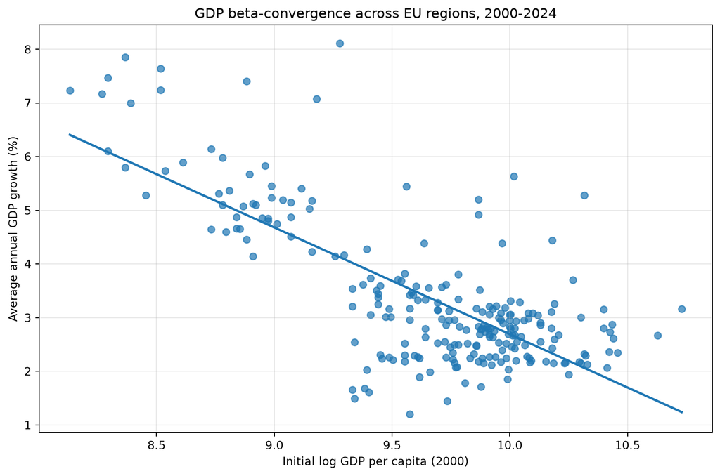

GDP beta-convergence across EU regions, 2000-2024

```python
import pandas as pd
import numpy as np
import matplotlib.pyplot as plt
from scipy.stats import linregress

# 1. Load the cleaned GDP dataset
gdp_q2 = pd.read_csv("data/clean/gdp.csv")

# Ensure variables are numeric
gdp_q2["year"] = pd.to_numeric(gdp_q2["year"], errors="coerce")
gdp_q2["gdp_pps"] = pd.to_numeric(gdp_q2["gdp_pps"], errors="coerce")

# 2. Select the beginning and end of the study period
gdp_period = gdp_q2[
    gdp_q2["year"].isin([2000, 2024])
].copy()

# 3. Arrange data so each region has one row
gdp_wide = gdp_period.pivot(
    index="geo",
    columns="year",
    values="gdp_pps"
)

# Keep regions with observations in both years
gdp_wide = gdp_wide.dropna(subset=[2000, 2024])

# Remove invalid or non-positive GDP observations
gdp_wide = gdp_wide[
    (gdp_wide[2000] > 0) &
    (gdp_wide[2024] > 0)
].copy()

# 4. Calculate initial GDP and annual economic growth
gdp_wide["initial_log_gdp"] = np.log(gdp_wide[2000])

gdp_wide["annual_growth"] = (
    np.log(gdp_wide[2024]) -
    np.log(gdp_wide[2000])
) / 24

gdp_wide["growth_percent"] = (
    (gdp_wide[2024] / gdp_wide[2000]) ** (1 / 24) - 1
) * 100

# 5. Run beta-convergence regression
gdp_model = linregress(
    gdp_wide["initial_log_gdp"],
    gdp_wide["annual_growth"]
)

# 6. Display regression results
print("GDP BETA-CONVERGENCE RESULTS")
print("=" * 40)

print("Number of regions:", len(gdp_wide))
print("Regression coefficient:", round(gdp_model.slope, 5))
print("R-squared:", round(gdp_model.rvalue ** 2, 3))
print("P-value:", f"{gdp_model.pvalue:.4g}")

if gdp_model.slope < 0 and gdp_model.pvalue < 0.05:
    print("Conclusion: Evidence of beta-convergence.")
else:
    print("Conclusion: No statistically significant evidence of beta-convergence.")

# 7. Compare growth across initial-income groups
gdp_wide["income_group"] = pd.qcut(
    gdp_wide[2000],
    q=4,
    labels=["Poorest", "Lower-middle", "Upper-middle", "Richest"]
)

quartile_results = gdp_wide.groupby(
    "income_group",
    observed=True
)["growth_percent"].mean()

print("\nAVERAGE ANNUAL GDP GROWTH BY INITIAL INCOME")
print(quartile_results.round(2))

# 8. Create scatter plot and regression line
plt.figure(figsize=(9, 6))

plt.scatter(
    gdp_wide["initial_log_gdp"],
    gdp_wide["annual_growth"] * 100,
    alpha=0.7
)

x = np.linspace(
    gdp_wide["initial_log_gdp"].min(),
    gdp_wide["initial_log_gdp"].max(),
    100
)

y = (
    gdp_model.intercept +
    gdp_model.slope * x
) * 100

plt.plot(x, y, linewidth=2)

plt.xlabel("Initial log GDP per capita (2000)")
plt.ylabel("Average annual GDP growth (%)")
plt.title("GDP beta-convergence across EU regions, 2000-2024")
plt.grid(alpha=0.3)

plt.tight_layout()
plt.show()
```

```
EMPLOYMENT CONVERGENCE RESULTS
------------------------------
Number of regions: 199
Regression coefficient: -0.3433
R-squared: 0.199
P-value: 4.2067900086364215e-11

AVERAGE CHANGE IN EMPLOYMENT RATE BY INITIAL EMPLOYMENT RATE (percentage points)
emp_group
Lowest          13.49
Lower-middle    11.45
Upper-middle     7.94
Highest          6.81
Name: employment_change, dtype: float64
```

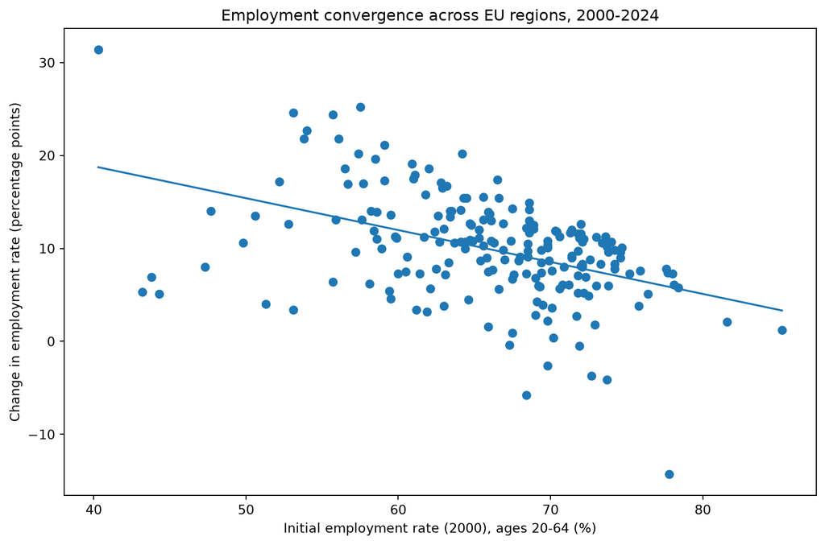

Employment convergence across EU regions, 2000-2024

```python
# Employment convergence: 2000-2024

emp = pd.read_csv("data/clean/emp.csv")

# Select initial and final employment rates
emp_period = emp[emp["year"].isin([2000, 2024])]

emp_wide = emp_period.pivot(
    index="geo",
    columns="year",
    values="emp_rate"
).dropna(subset=[2000, 2024])

# Calculate percentage-point change
emp_wide["employment_change"] = (
    emp_wide[2024] - emp_wide[2000]
)

# Regression: initial employment rate vs change
emp_model = linregress(
    emp_wide[2000],
    emp_wide["employment_change"]
)

print("EMPLOYMENT CONVERGENCE RESULTS")
print("------------------------------")
print("Number of regions:", len(emp_wide))
print("Regression coefficient:", round(emp_model.slope, 4))
print("R-squared:", round(emp_model.rvalue**2, 3))
print("P-value:", emp_model.pvalue)

# Compare the change across initial-employment groups (same method as for GDP)
emp_wide["emp_group"] = pd.qcut(
    emp_wide[2000],
    q=4,
    labels=["Lowest", "Lower-middle", "Upper-middle", "Highest"]
)

print("\nAVERAGE CHANGE IN EMPLOYMENT RATE BY INITIAL EMPLOYMENT RATE (percentage points)")
print(emp_wide.groupby("emp_group", observed=True)["employment_change"].mean().round(2))

# Scatter plot
plt.figure(figsize=(9, 6))

plt.scatter(
    emp_wide[2000],
    emp_wide["employment_change"]
)

x = np.linspace(
    emp_wide[2000].min(),
    emp_wide[2000].max(),
    100
)

plt.plot(
    x,
    emp_model.intercept + emp_model.slope * x
)

plt.xlabel("Initial employment rate (2000), ages 20-64 (%)")
plt.ylabel("Change in employment rate (percentage points)")
plt.title("Employment convergence across EU regions, 2000-2024")

plt.tight_layout()
plt.show()
```

### Results and interpretation

The results provide evidence of beta-convergence across EU regions between 2000 and 2024. The regression analysis shows a negative relationship between initial GDP per capita and subsequent economic growth. The regression coefficient is approximately -0.01988, with an R-squared of 0.547. The relationship is statistically significant (p < 0.001).

This suggests that regions with lower initial GDP per capita generally experienced faster economic growth than regions that were initially wealthier. The comparison between the poorest and richest quarters supports this finding. The poorest quarter recorded average annual GDP growth of approximately 5.20%, compared with 2.81% for the richest quarter.

The employment analysis provides additional evidence of convergence. Across the 199 regions with employment data for both 2000 and 2024, the regression coefficient is approximately -0.3433. This indicates that regions with lower initial employment rates generally experienced larger improvements in employment. The quarter of regions with the lowest initial employment rates recorded an average increase of 13.49 percentage points, compared with 6.81 percentage points for the quarter with the highest initial rates.

Overall, the findings suggest that poorer EU regions experienced faster economic growth and that regions with initially lower employment rates made greater improvements in employment. However, the results do not establish that lower initial income causes faster growth. They demonstrate an association between initial regional conditions and subsequent changes.

### Robustness Check: Alternative Employment Age Group (15–64)

The main employment measure covers ages 20-64. To check that the result does not depend on this choice, we repeat the regression for ages 15-64, using exactly the same regions for both age groups.

```python
def employment_change(file):
    """One row per region: employment rate in 2000, 2024 and the change in percentage points."""
    d = pd.read_csv(file)                       # no fallback: if a file is missing, this stops with an error
    d = d[d["year"].isin([2000, 2024])]
    w = d.pivot(index="geo", columns="year", values="emp_rate").dropna(subset=[2000, 2024]).copy()
    w["change"] = w[2024] - w[2000]
    return w

emp_20 = employment_change("data/clean/emp.csv")
emp_15 = employment_change("data/clean/emp_15_64.csv")

# Same regions for both age groups
common = emp_20.index.intersection(emp_15.index)
emp_20, emp_15 = emp_20.loc[common], emp_15.loc[common]

# Safety check: stop if the two "age groups" are the same numbers (this is what went wrong before)
assert not emp_20[2000].equals(emp_15[2000]), "20-64 and 15-64 data are identical: check emp_15_64.csv"

def fit(w, label):
    m = linregress(w[2000], w["change"])
    return {"Age group": label, "Regions": len(w), "Coefficient": m.slope,
            "Std. error": m.stderr, "R-squared": m.rvalue ** 2, "P-value": m.pvalue}

rob_emp = pd.DataFrame([fit(emp_20, "20-64 (main)"), fit(emp_15, "15-64 (check)")])
converges = (rob_emp["Coefficient"] < 0) & (rob_emp["P-value"] < 0.05)

print(f"Average employment rate in 2000: 20-64 {emp_20[2000].mean():.1f}%, 15-64 {emp_15[2000].mean():.1f}%")
print(f"Correlation of the 2000-2024 changes under the two definitions: {emp_20['change'].corr(emp_15['change']):.2f}")
if converges.all():
    print("Conclusion: convergence remains under both age definitions.")
elif converges.iloc[0]:
    print("Conclusion: the convergence finding is sensitive to the age group.")
else:
    print("Conclusion: the main convergence finding needs further investigation.")

rob_emp.assign(**{"P-value": rob_emp["P-value"].map("{:.1e}".format)}).round(
    {"Coefficient": 3, "Std. error": 3, "R-squared": 3})
```

```
Average employment rate in 2000: 20-64 65.9%, 15-64 61.4%
Correlation of the 2000-2024 changes under the two definitions: 0.99
Conclusion: convergence remains under both age definitions.
```

Table 7: Employment convergence, 2000-2024: ages 20-64 (main) and ages 15-64 (check), same regions

|  | Age group | Regions | Coefficient | Std. error | R-squared | P-value |
| --- | --- | --- | --- | --- | --- | --- |
| 0 | 20-64 (main) | 199 | -0.343 | 0.049 | 0.199 | 4.2e-11 |
| 1 | 15-64 (check) | 199 | -0.270 | 0.047 | 0.143 | 3.7e-08 |

The result holds with the wider age group. For ages 15-64 the coefficient is -0.270 (20-64: -0.343), so regions that started with lower employment still had larger increases, and the relationship is still statistically significant (p < 0.001). It is somewhat weaker: R-squared falls from 0.199 to 0.143, which means that initial employment explains about 14% of the change instead of 20%. We did not test whether the two coefficients differ significantly. The 15-64 rates are about 4.5 percentage points lower on average in 2000 (61.4% against 65.9%), which fits with many 15-19 year-olds being in education and not working, but we did not test this explanation. The two measures give almost the same change for each region (correlation 0.99), so the age group does not change which regions improved most. This check only changes the age group. It does not address the choice of regions or measurement error (see the limitations).

### Limitations of this analysis

- **Different regional samples for GDP and employment.** The GDP and employment analyses do not contain exactly the same number of regions because data availability differs between the two indicators. This limits direct comparisons between economic growth and employment improvements. The results should therefore be interpreted as separate measures of regional convergence.
- **Correlation does not establish causation.** The regression analysis identifies a relationship between initial regional GDP per capita and subsequent economic growth. However, it does not establish that being poorer causes a region to grow faster. Other factors, such as investment, infrastructure, industrial structure, education and government policies, may also influence regional economic performance.
- **Breaks in the employment series.** Many 2024 employment values are flagged by Eurostat as a break in the series or a different definition (see the data section). Part of the change between 2000 and 2024 may therefore come from a change in how employment was measured and not from a real change. We did not test this.
- **Measurement error in the starting values.** Regional employment rates come from a survey, so each value has some sampling error. A region whose 2000 rate was too low by chance will tend to show a larger increase by 2024, and the reverse for a region whose rate was too high. This can make the negative coefficient look stronger than the true convergence. We did not correct for it, so the coefficients should be read as an upper estimate of how strongly low-employment regions caught up.
- **Limited observation period.** The analysis compares the beginning and end of the 2000–2024 period. Although this provides an overview of long-term changes, it does not fully capture economic fluctuations, financial crises, the COVID-19 pandemic or other events that may have affected individual regions during the period.

## Question 3: Which groups of regions behave alike?

### Measure

We describe every region by the share of its gross value added that comes from each of the six sectors in 2000, the first year of the period. We use the start of the period so that the sector structure is not itself a result of the growth we compare it with later. Regions with a similar mix are put in the same group with k-means clustering. The shares are standardised so that every sector counts equally, each solution is the best of 20 random starts, and the random seed is fixed so that the result can be repeated. The number of groups is chosen with the silhouette score (1 means clearly separated groups, 0 means overlapping groups) and with how well the groups can be described.

To separate geography from industrial structure we use the country as the measure of geography. We look at how much of the variation in each sector lies between countries, how many countries each group covers, and how well the groups agree with the countries (adjusted Rand index, ARI: 1 means identical, about 0 means no more agreement than chance). Finally we check whether the groups behave alike: their income, growth (same definition as in Question 2), change in employment rate, and the spread of income inside each group.

### Data and sample

Sector shares exist for 233 regions in 2000 (Belgium has none before 2003). Of these, 232 have GDP in 2000 and 2024, and 188 also have an employment rate in both years. The other 44 have no employment value for 2000 (see the join check in the data section). Results on income therefore use 232 regions and results on employment 188.

### Results

The silhouette score is between 0.25 and 0.28 for every number of groups (Table 8). We use five groups, because they can be described clearly.

```python
import matplotlib.pyplot as plt
from scipy import stats
from sklearn.cluster import AgglomerativeClustering, KMeans
from sklearn.metrics import adjusted_rand_score, silhouette_samples, silhouette_score
from sklearn.preprocessing import StandardScaler

q3_sectors = ["A", "B-E", "F", "G-J", "K-N", "O-U"]
q3_short = {"A": "Agriculture", "B-E": "Industry", "F": "Construction", "G-J": "Trade, transport, ICT",
            "K-N": "Finance, business services", "O-U": "Public services"}

def q3_shares(year, table=sec_clean):
    """One row per region, one column per sector: share of gross value added (%), only regions with all six."""
    w = table[table["year"] == year].pivot(index="geo", columns="sector", values="share_pct")
    return w[q3_sectors].dropna()

Q3_YEAR = 2000                                   # structure at the start of the period
q3_W = q3_shares(Q3_YEAR)
q3_X = StandardScaler().fit_transform(q3_W)      # every sector counts equally in the distances

rows = []
for k in range(2, 9):
    km = KMeans(n_clusters=k, n_init=20, random_state=42).fit(q3_X)
    rows.append({"groups k": k, "silhouette": silhouette_score(q3_X, km.labels_), "inertia": km.inertia_})
q3_k = pd.DataFrame(rows).set_index("groups k").round(3)
q3_k
```

Table 8: Silhouette score and inertia for 2 to 8 groups (sector shares in 2000)

| groups k | silhouette | inertia |
| --- | --- | --- |
| 2 | 0.246 | 1069.828 |
| 3 | 0.251 | 892.999 |
| 4 | 0.248 | 760.459 |
| 5 | 0.266 | 636.145 |
| 6 | 0.276 | 557.644 |
| 7 | 0.262 | 499.801 |
| 8 | 0.269 | 458.111 |

Table 9 shows what the five groups look like, named after the sector in which each is furthest above the average.

```python
Q3_K = 5
q3_km = KMeans(n_clusters=Q3_K, n_init=20, random_state=42).fit(q3_X)
q3_num = pd.Series(q3_km.labels_, index=q3_W.index)

# Name each group after the sector where it is furthest above the average of all regions
q3_above = q3_W.groupby(q3_num).mean() - q3_W.mean()
q3_names = q3_above.idxmax(axis=1).map(q3_short)
assert q3_names.is_unique, "two groups got the same name: check the profile table"
q3_lab = q3_num.map(q3_names).rename("group")

q3_prof = q3_W.groupby(q3_lab).mean().round(1)
q3_prof.columns = [q3_short[c] for c in q3_prof.columns]
q3_prof.insert(0, "regions", q3_lab.value_counts())
q3_prof.loc["All regions"] = [len(q3_W)] + q3_W.mean().round(1).tolist()
q3_prof["regions"] = q3_prof["regions"].astype(int)
q3_prof
```

Table 9: The five groups: average sector shares of gross value added in 2000 (%)

| group | regions | Agriculture | Industry | Construction | Trade, transport, ICT | Finance, business services | Public services |
| --- | --- | --- | --- | --- | --- | --- | --- |
| Agriculture | 27 | 14.3 | 25.8 | 6.1 | 21.9 | 14.6 | 17.3 |
| Finance, business services | 34 | 1.2 | 16.1 | 4.8 | 28.0 | 29.2 | 20.6 |
| Industry | 88 | 3.0 | 28.9 | 5.5 | 20.2 | 20.7 | 21.6 |
| Public services | 27 | 3.7 | 13.8 | 6.6 | 21.6 | 21.1 | 33.2 |
| Trade, transport, ICT | 57 | 4.8 | 20.6 | 8.6 | 29.7 | 16.3 | 19.9 |
| All regions | 233 | 4.6 | 22.9 | 6.4 | 24.0 | 20.2 | 21.9 |

Table 10 shows where the groups are, and how much of the variation in each sector lies between countries.

```python
q3_country = pd.Series(q3_W.index.str[:2], index=q3_W.index, name="country")
q3_ct = pd.crosstab(q3_country, q3_lab)

def top3(col):
    t = q3_ct[col].sort_values(ascending=False)
    return ", ".join(f"{c} {n}" for c, n in t[t > 0].head(3).items())

q3_geo = pd.DataFrame({"regions": q3_ct.sum(), "countries": (q3_ct > 0).sum(),
                       "largest countries (regions)": [top3(c) for c in q3_ct.columns]})

# Share of the variation in each sector that lies between countries (eta squared)
def eta2(x):
    m = x.groupby(q3_country).transform("mean")
    return 1 - ((x - m) ** 2).sum() / ((x - x.mean()) ** 2).sum()
q3_eta = pd.Series({q3_short[c]: eta2(q3_W[c]) for c in q3_sectors}).round(2)

print("Share of the variation in each sector that is between countries:", q3_eta.to_dict())
print(f"Agreement between groups and countries (adjusted Rand index): {adjusted_rand_score(q3_country, q3_lab):.2f}")
q3_geo
```

```
Share of the variation in each sector that is between countries: {'Agriculture': 0.57, 'Industry': 0.28, 'Construction': 0.62, 'Trade, transport, ICT': 0.36, 'Finance, business services': 0.55, 'Public services': 0.34}
Agreement between groups and countries (adjusted Rand index): 0.11
```

Table 10: Where the groups are: number of countries and the three countries with most regions in each group

| group | regions | countries | largest countries (regions) |
| --- | --- | --- | --- |
| Agriculture | 27 | 8 | RO 7, BG 5, EL 5 |
| Finance, business services | 34 | 17 | DE 7, IT 6, NL 5 |
| Industry | 88 | 14 | DE 24, FR 14, IT 9 |
| Public services | 27 | 6 | FR 10, DE 7, IT 6 |
| Trade, transport, ICT | 57 | 14 | ES 15, PL 15, EL 7 |

Table 11 shows how the groups did over 2000-2024. Employment changes use fewer regions (column “regions with employment”).

```python
q3_gdp = pd.read_csv("data/clean/gdp.csv")
q3_g = q3_gdp[q3_gdp["year"].isin([2000, 2024])].pivot(index="geo", columns="year", values="gdp_pps").dropna()
q3_emp = pd.read_csv("data/clean/emp.csv")
q3_e = q3_emp[q3_emp["year"].isin([2000, 2024])].pivot(index="geo", columns="year", values="emp_rate").dropna()

q3_d = pd.DataFrame({"group": q3_lab}).join(q3_g, how="inner")
q3_d["ln_gdp_2000"] = np.log(q3_d[2000])
q3_d["growth_pct"] = ((q3_d[2024] / q3_d[2000]) ** (1 / 24) - 1) * 100     # same definition as in Question 2
q3_d["emp_change"] = (q3_e[2024] - q3_e[2000]).reindex(q3_d.index)

q3_grp = q3_d.groupby("group")
q3_out = pd.DataFrame({
    "regions": q3_grp.size(),
    "GDP 2000 (median)": q3_grp[2000].median(), "GDP 2024 (median)": q3_grp[2024].median(),
    "growth % a year": q3_grp["growth_pct"].mean(),
    "regions with employment": q3_grp["emp_change"].count(), "employment change (pp)": q3_grp["emp_change"].mean(),
    "spread 2000": q3_grp[2000].apply(lambda x: np.log(x).std()), "spread 2024": q3_grp[2024].apply(lambda x: np.log(x).std()),
}).sort_values("GDP 2000 (median)")
q3_out.round({"GDP 2000 (median)": 0, "GDP 2024 (median)": 0, "growth % a year": 2,
              "employment change (pp)": 1, "spread 2000": 2, "spread 2024": 2})
```

Table 11: How the groups did, 2000-2024: income per head, growth, employment and the spread inside each group

| group | regions | GDP 2000 (median) | GDP 2024 (median) | growth % a year | regions with employment | employment change (pp) | spread 2000 | spread 2024 |
| --- | --- | --- | --- | --- | --- | --- | --- | --- |
| Agriculture | 27 | 6900.0 | 22600.0 | 4.91 | 17 | 4.7 | 0.54 | 0.21 |
| Trade, transport, ICT | 57 | 13200.0 | 30100.0 | 3.89 | 51 | 11.5 | 0.43 | 0.28 |
| Public services | 26 | 15000.0 | 29250.0 | 2.82 | 20 | 11.2 | 0.14 | 0.20 |
| Industry | 88 | 20350.0 | 38450.0 | 3.01 | 72 | 10.5 | 0.32 | 0.24 |
| Finance, business services | 34 | 27700.0 | 53650.0 | 3.17 | 28 | 9.5 | 0.28 | 0.27 |

```python
# Do the groups explain growth? Differences between groups, then what the groups add to income and country
def r2(y, X):
    X = np.column_stack([np.ones(len(y)), X])
    b = np.linalg.lstsq(X, y, rcond=None)[0]
    return 1 - (y - X @ b).var() / y.var(), X.shape[1]

y = q3_d["growth_pct"].values
G = pd.get_dummies(q3_d["group"], drop_first=True).values.astype(float)            # group dummies
C = pd.get_dummies(q3_d.index.str[:2], drop_first=True).values.astype(float)       # country dummies
L = q3_d[["ln_gdp_2000"]].values
r_g, _ = r2(y, G); r_l, _ = r2(y, L); r_lg, _ = r2(y, np.column_stack([L, G]))
r_c, k_c = r2(y, C); r_cg, k_cg = r2(y, np.column_stack([C, G]))
F = ((r_cg - r_c) / (k_cg - k_c)) / ((1 - r_cg) / (len(y) - k_cg))

kw = stats.kruskal(*[x["growth_pct"].values for _, x in q3_d.groupby("group")])
print(f"Regions: {len(q3_d)}. Growth differs between groups (Kruskal-Wallis): H = {kw.statistic:.1f}, p = {kw.pvalue:.1g}")
print(f"Share of the differences in growth explained (R-squared): groups alone {r_g:.2f}; initial income alone {r_l:.2f}; income and groups {r_lg:.2f}")
print(f"With country dummies: countries alone {r_c:.3f}; countries and groups {r_cg:.3f}; F-test for the groups: F = {F:.1f}, p = {stats.f.sf(F, k_cg - k_c, len(y) - k_cg):.2g}")
```

```
Regions: 232. Growth differs between groups (Kruskal-Wallis): H = 28.0, p = 1e-05
Share of the differences in growth explained (R-squared): groups alone 0.21; initial income alone 0.55; income and groups 0.64
With country dummies: countries alone 0.927; countries and groups 0.932; F-test for the groups: F = 4.1, p = 0.0033
```

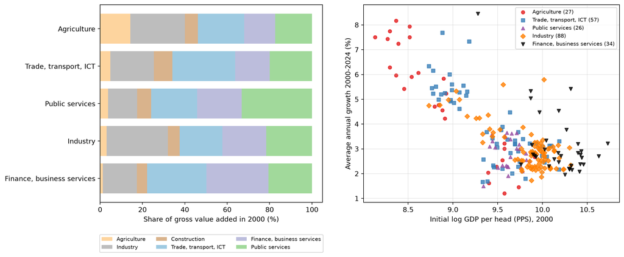

Figure 2: Left: average sector shares in each group (2000). Right: initial income and growth of the regions, by group.

```python
order = q3_out.index.tolist()                                  # groups from poorest to richest in 2000
cols = dict(zip(order, ["#e41a1c", "#377eb8", "#984ea3", "#ff7f00", "#000000"]))      # strong colours for groups
marks = dict(zip(order, ["o", "s", "^", "D", "v"]))                                    # and a marker per group
fig, (ax1, ax2) = plt.subplots(1, 2, figsize=(13, 5.5), gridspec_kw={"width_ratios": [1, 1.15]})

prof = q3_W.groupby(q3_lab).mean().loc[order]
left = np.zeros(len(order))
palette = ["#fdd49e", "#bdbdbd", "#d9b38c", "#9ecae1", "#bcbddc", "#a1d99b"]           # light colours for sectors
for sec, colr in zip(q3_sectors, palette):
    ax1.barh(order, prof[sec], left=left, label=q3_short[sec], color=colr)
    left += prof[sec].values
ax1.set_xlabel("Share of gross value added in 2000 (%)")
ax1.legend(loc="upper center", bbox_to_anchor=(0.5, -0.15), ncol=3, fontsize=8)
ax1.invert_yaxis()

for grp in order:
    d = q3_d[q3_d["group"] == grp]
    ax2.scatter(d["ln_gdp_2000"], d["growth_pct"], s=26, alpha=0.8, color=cols[grp], marker=marks[grp], label=f"{grp} ({len(d)})")
ax2.set_xlabel("Initial log GDP per head (PPS), 2000")
ax2.set_ylabel("Average annual growth 2000-2024 (%)")
ax2.legend(fontsize=8)
ax2.grid(alpha=0.3)
fig.tight_layout()
plt.show()
```

### Interpretation

**Short answer.** Regions fall into five loose types of economy. The types are partly national, and they tell us little about growth once we know where a region lies and how rich it was at the start.

**The groups.** The largest group is *industry* (88 regions, 29% of value added from industry). *Trade, transport and ICT* has 57 regions (30% from this sector, and the highest construction share), *finance and business services* has 34 (29%, and almost no agriculture), and *public services* and *agriculture* have 27 regions each (33% and 14% from their own sector). The silhouette scores are low for every number of groups (0.25 to 0.28) and do not point to one best number. Regions therefore change gradually from one type to another; the groups are a useful summary, not separate boxes. The two groups with 27 regions are small, so statements about them deserve more care.

**Geography or industrial structure?** Both matter. The country explains a large part of the differences in sector mix: 62% of the variation in construction, 57% in agriculture and 55% in finance and business services, but only 28% in industry. Some groups sit in a few countries. The public services group covers 6 countries, and 23 of its 27 regions are French, German or Italian. In the agriculture group 17 of 27 regions are in Romania, Bulgaria and Greece, and 30 of the 57 trade, transport and ICT regions are Spanish or Polish. Other groups cross borders: finance and business services is spread over 17 countries and industry over 14. Overall the groups agree little with the countries (ARI 0.11). The same type of economy therefore appears on both sides of borders, but where a region lies strongly shapes which type it is. We cannot separate the two completely, because the country is only a rough stand-in for geography; our files contain no distances.

**Do the groups behave alike?** They differ in growth: the agriculture group grew by 4.9% a year, trade, transport and ICT by 3.9%, finance and business services by 3.2%, industry by 3.0% and public services by 2.8% (Kruskal-Wallis p = 1e-05). But this order follows the starting income. The median GDP per head in 2000 was 6,900 PPS in the agriculture group and 27,700 in the finance group. Initial income alone explains 55% of the differences in growth between regions, and adding the group raises this to 64%. When the country is also taken into account (countries alone explain 93%), the group adds only about half a percentage point (93.2% against 92.7%; the F-test gives p = 0.003, so the effect is detectable but small). Belonging to a sector group therefore says little about growth beyond the region’s country and starting level. The groups behave alike mainly because their regions started at similar income levels and lie in similar countries.

**Where the pattern does not hold.** Inside the groups, the spread of income fell strongly for agriculture (0.54 to 0.21) and for trade, transport and ICT (0.43 to 0.28), less for industry (0.32 to 0.24), hardly for finance (0.28 to 0.27), and *rose* for public services (0.14 to 0.20). The regions of the public services group, mostly French, German and Italian, moved apart, so this is the group that does not follow convergence. The groups with the strongest fall contain regions from poorer and richer countries (for example Romania and Spain in the agriculture group, Poland and Austria in the trade group). The fall may therefore reflect countries catching up and not a sector effect, but we have not tested this here.

**Employment.** The employment rate rose by 9.5 to 11.5 percentage points in four of the groups (trade 11.5, public services 11.2, industry 10.5, finance 9.5) and by 4.7 points in the agriculture group, which has only 17 regions with employment data. Sector group is not a strong sign of how much employment grew.

**Structure itself changes.** Between 2000 and 2023 the average share of finance and business services rose by 3.1 percentage points, while agriculture fell by 1.6 and industry by 1.5 (Table 12). 71 regions changed their finance share by more than 5 points. The groups describe the economy at the start of the period, not a fixed type.

```python
q3_w23 = q3_shares(2023).loc[q3_W.index]
q3_chg = pd.DataFrame({"2000": q3_W.mean(), "2023": q3_w23.mean()})
q3_chg["change (pp)"] = q3_chg["2023"] - q3_chg["2000"]
q3_chg["regions that moved by more than 5 pp"] = ((q3_w23 - q3_W).abs() > 5).sum()
q3_chg.index = [q3_short[c] for c in q3_chg.index]
q3_chg.round(1)
```

Table 12: How sector structure changed, 2000 to 2023 (average share of the 233 regions, %)

|  | 2000 | 2023 | change (pp) | regions that moved by more than 5 pp |
| --- | --- | --- | --- | --- |
| Agriculture | 4.6 | 3.0 | -1.6 | 19 |
| Industry | 22.9 | 21.4 | -1.5 | 66 |
| Construction | 6.4 | 6.0 | -0.4 | 10 |
| Trade, transport, ICT | 24.0 | 23.5 | -0.6 | 17 |
| Finance, business services | 20.2 | 23.3 | 3.1 | 71 |
| Public services | 21.9 | 22.8 | 0.9 | 19 |

### Robustness checks

We repeated the grouping with other choices (Table 13). The agreement with the main solution is moderate: 0.66 across random starts (a few starts give quite different groups, the lowest agreement is 0.40), 0.65 with a different method, and 0.59 with ten finer sectors instead of six. Using shares of the sum of the six sectors instead of the total changes nothing. Only 8 of 233 regions lie closer to another group than to their own. Groups found from the structure in 2003 agree with the main groups (0.62), but groups found from 2010 or later do not (0.22 to 0.29), because sector structure changed. The broad picture is stable, the exact membership is not.

```python
q3_gva = pd.read_csv("data/clean/gva.csv")

def q3_fit(W, k=5, seed=42, n_init=20):
    X = StandardScaler().fit_transform(W)
    return pd.Series(KMeans(n_clusters=k, n_init=n_init, random_state=seed).fit(X).labels_, index=W.index)

def ari(other):
    c = q3_num.index.intersection(other.index)
    return adjusted_rand_score(q3_num[c], other[c])

res = []
starts = [ari(q3_fit(q3_W, seed=s, n_init=1)) for s in range(1, 31)]
res.append(("30 single random starts (median; lowest to highest)", f"{np.median(starts):.2f}  ({min(starts):.2f} to {max(starts):.2f})", len(q3_W)))
ward = pd.Series(AgglomerativeClustering(n_clusters=5, linkage="ward").fit(q3_X).labels_, index=q3_W.index)
res.append(("Different method (hierarchical, Ward)", f"{ari(ward):.2f}", len(q3_W)))

ten = ["A", "B-E", "F", "G-I", "J", "K", "L", "M_N", "O-Q", "R-U"]            # finer, non-overlapping sectors
w10 = q3_gva[(q3_gva["year"] == 2000) & q3_gva["sector"].isin(ten)].pivot(index="geo", columns="sector", values="gva_meur").dropna()
res.append(("Ten finer sectors instead of six", f"{ari(q3_fit(w10.div(w10.sum(axis=1), axis=0) * 100)):.2f}", len(w10)))

w6 = q3_gva[(q3_gva["year"] == 2000) & q3_gva["sector"].isin(q3_sectors)].pivot(index="geo", columns="sector", values="gva_meur").dropna()
res.append(("Shares of the sum of the six sectors (not of the total)", f"{ari(q3_fit(w6.div(w6.sum(axis=1), axis=0) * 100)):.2f}", len(w6)))

for yr in (2003, 2010, 2019, 2023):
    res.append((f"Groups found from the structure in {yr} (same regions)", f"{ari(q3_fit(q3_shares(yr))):.2f}", len(q3_shares(yr))))

q3_rob = pd.DataFrame(res, columns=["Check", "Agreement (ARI)", "Regions"]).set_index("Check")
sil = silhouette_samples(q3_X, q3_num)
print(f"Regions closer to another group than to their own (negative silhouette): {(sil < 0).sum()} of {len(sil)}")
q3_rob
```

```
Regions closer to another group than to their own (negative silhouette): 8 of 233
```

Table 13: Do the groups depend on our choices? Agreement (adjusted Rand index) with the main solution

| Check | Agreement (ARI) | Regions |
| --- | --- | --- |
| 30 single random starts (median; lowest to highest) | 0.66 (0.40 to 0.98) | 233 |
| Different method (hierarchical, Ward) | 0.65 | 233 |
| Ten finer sectors instead of six | 0.59 | 233 |
| Shares of the sum of the six sectors (not of the total) | 1.00 | 233 |
| Groups found from the structure in 2003 (same regions) | 0.62 | 244 |
| Groups found from the structure in 2010 (same regions) | 0.29 | 244 |
| Groups found from the structure in 2019 (same regions) | 0.22 | 244 |
| Groups found from the structure in 2023 (same regions) | 0.23 | 244 |

### Limitations of this analysis

- **Weak separation.** The silhouette scores (0.25 to 0.28) show overlapping groups, and no number of groups is clearly best. We chose five because they can be described. With another k the membership changes. The groups describe tendencies, not hard types.
- **The groups belong to 2000.** Groups found from later years agree only a little with them (ARI 0.22 to 0.29). A reader who wants the sector types of today needs a new grouping, and the link to growth would differ.
- **Sample.** Belgium (11 regions) is not in the sample because it has no sector values before 2003. For employment we have 188 regions, because 44 have no employment value for 2000. Germany, the Netherlands and Poland have no 2024 values, and the 2023 and 2024 values are provisional or estimated. The 2009 values of some regions carry a break flag.
- **Six broad sectors.** Trade, transport, accommodation and ICT are in one group, and finance, real estate and professional services in another. A finer split gives somewhat different groups (ARI 0.59). The sector shares are at current prices, so they also reflect price changes between sectors.
- **Geography is only the country.** The files contain no distances, so we cannot say how much a region is like its neighbours across a border. The country is a rough stand-in.
- **No cause.** The groups are measured in 2000 and growth comes later, but this does not show that structure causes growth. Differences between groups may come from the starting income, the country, or other things we did not measure.
- **Small groups.** The agriculture and public services groups have 27 regions each, and the employment change of the agriculture group rests on 17 regions.
- **What would change our answer.** A different start year or a finer sector split would move many regions between groups. If the groups explained growth within countries by more than half a percentage point, the answer to “structure or geography” would lean toward structure.

#### Appendix: the regions in each group

```python
q3_list = q3_lab.reset_index().rename(columns={"geo": "region"}).sort_values(["group", "region"])
q3_list.to_csv("data/clean/q3_region_groups.csv", index=False)          # kept for Question 4 and the slides
q3_list.groupby("group")["region"].apply(lambda s: " ".join(s)).loc[q3_out.index].to_frame("regions")
```

Table 14: Appendix: the regions in each group (NUTS2 codes)

| group | regions |
| --- | --- |
| Agriculture | BG31 BG32 BG33 BG34 BG42 EL51 EL53 EL63 EL64 E... |
| Trade, transport, ICT | AT11 AT12 AT21 AT32 AT33 BG41 CY00 EE00 EL41 E... |
| Public services | DE40 DE80 DE93 DED2 DED5 DEE0 DEG0 DK02 ES63 E... |
| Industry | AT22 AT31 AT34 CZ02 CZ03 CZ04 CZ05 CZ06 CZ07 C... |
| Finance, business services | AT13 CZ01 DE21 DE30 DE60 DE71 DEA1 DEA2 DEF0 D... |

## Question 4: Where do the two convergence tests disagree?

### Measure

Question 4 puts the two tests from Questions 1 and 2 side by side. The **spread test** is the standard deviation of the logarithm of the indicator across regions, year by year: a smaller value means the regions are more alike. The **catching-up test** compares the change between two years with the starting value: a negative slope means that regions that started worse improved more. For both tests a negative number leads to convergence. We apply both to GDP per head, employment and youth unemployment (ages 15-24, with 15-29 as a check), for 2000-2024 and for four sub-periods: before the crisis (2000-2008), the crisis (2008-2013), the recovery (2013-2024) and everything after 2008 (2008-2024). Question 1 only measured the spread of GDP, so the spread of employment and of youth unemployment is new here. For GDP, the catching-up test is the same as in Question 2 (log growth against log starting income). For employment and youth unemployment, we use the change in percentage points against the starting rate. The slopes are in different units, so we compare their direction and their R-squared, not their size.

### Youth unemployment: ages 15-24 and 15-29

```python
def spread(w):
    return pd.DataFrame({"regions": w.notna().sum(), "sigma_log": np.log(w).std()})

S24, S29 = spread(w24), spread(w29)
years = [2000, 2005, 2008, 2013, 2019, 2024]
sigma_table = pd.DataFrame({
    "15-24 regions": S24.loc[years, "regions"], "15-24 spread": S24.loc[years, "sigma_log"],
    "15-29 regions": S29.loc[years, "regions"], "15-29 spread": S29.loc[years, "sigma_log"],
}).round(3)
sigma_table.index.name = "Year"
sigma_table
```

Table 15: Spread of log youth unemployment across regions (all regions with a value that year)

| Year | 15-24 regions | 15-24 spread | 15-29 regions | 15-29 spread |
| --- | --- | --- | --- | --- |
| 2000 | 166 | 0.684 | 182 | 0.679 |
| 2005 | 218 | 0.441 | 222 | 0.439 |
| 2008 | 214 | 0.482 | 227 | 0.492 |
| 2013 | 228 | 0.652 | 235 | 0.641 |
| 2019 | 193 | 0.694 | 230 | 0.706 |
| 2024 | 180 | 0.511 | 207 | 0.542 |

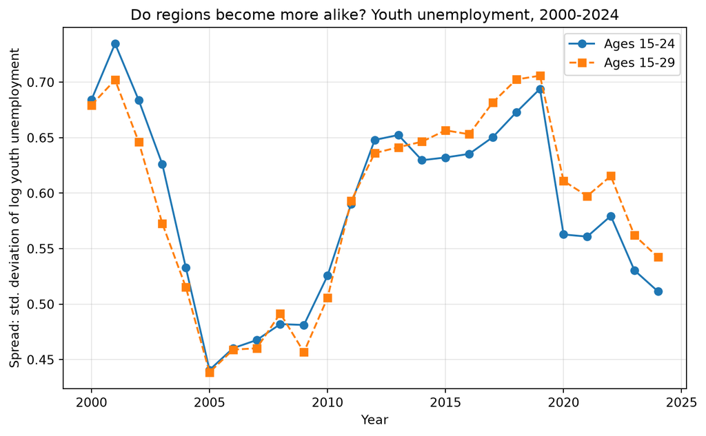

Figure 3: Spread of youth unemployment across EU regions, 2000-2024

```python
fig, ax = plt.subplots(figsize=(8, 5))
ax.plot(S24.index, S24["sigma_log"], "o-", label="Ages 15-24")
ax.plot(S29.index, S29["sigma_log"], "s--", label="Ages 15-29")
ax.set_xlabel("Year")
ax.set_ylabel("Spread: std. deviation of log youth unemployment")
ax.set_title("Do regions become more alike? Youth unemployment, 2000-2024")
ax.legend()
ax.grid(alpha=0.3)
fig.tight_layout()
plt.show()
```

The spread of youth unemployment fell from 0.68 in 2000 to 0.44 in 2005, rose to 0.69 in 2019 and fell again to 0.51 in 2024 (ages 15-24; ages 15-29 are almost identical, Table 15, Figure 3). This means that the narrowing between 2000 and 2024 (-25% with all regions available each year) is not a steady trend: in 2019 the regions were no more alike than in 2000.

Two jumps in the line are partly caused by the data and not by the regions. In 2005 Eurostat flags 218 values as a break in the series. The spread falls from 0.533 to 0.443 even when we use only the 180 regions that have a value in both 2004 and 2005, so the regions that join the sample do not explain it. From 2020 none of the 20 German regions that had a value in 2019 has one. German regions have low youth unemployment (about 6% in 2019 against about 21% elsewhere), so losing them makes the spread look smaller. With only the 165 regions that have a value in both years the spread falls from 0.646 to 0.556 and not from 0.694 to 0.563, so roughly a third of the fall comes from the missing regions.

```python
def beta(w, label):
    d = w.dropna(subset=[2000, 2024]).copy()      # only regions with both years
    d["change"] = d[2024] - d[2000]               # change in percentage points
    m = linregress(d[2000], d["change"])          # line: change versus the value in 2000
    row = {"age group": label, "regions": len(d), "slope": m.slope,
           "R-squared": m.rvalue ** 2, "p-value": m.pvalue}
    return d, m, row

d24, m24, r24 = beta(w24, "15-24")
d29, m29, r29 = beta(w29, "15-29")
beta_table = pd.DataFrame([r24, r29]).set_index("age group")
beta_table["p-value"] = beta_table["p-value"].map("{:.1e}".format)
beta_table.round({"slope": 3, "R-squared": 3})
```

Table 16: Catching-up test for youth unemployment, 2000-2024: change in percentage points against the rate in 2000

| age group | regions | slope | R-squared | p-value |
| --- | --- | --- | --- | --- |
| 15-24 | 123 | -0.498 | 0.463 | 4.9e-18 |
| 15-29 | 151 | -0.565 | 0.510 | 7.8e-25 |

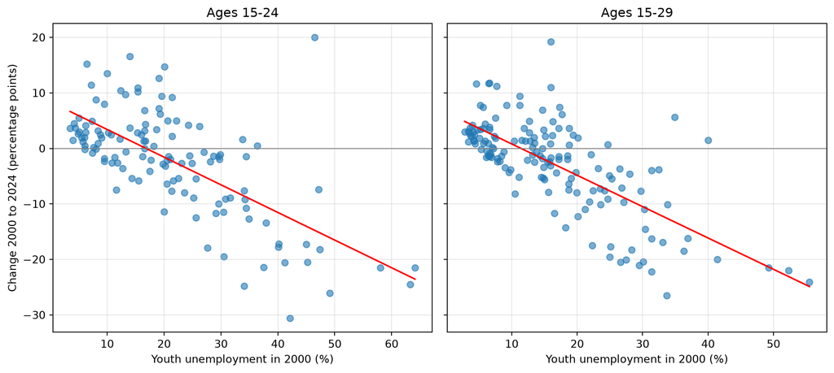

Figure 4: Change in youth unemployment 2000-2024 against the rate in 2000, one dot per region

```python
fig, axes = plt.subplots(1, 2, figsize=(11, 5), sharey=True)
for ax, d, m, label in [(axes[0], d24, m24, "Ages 15-24"), (axes[1], d29, m29, "Ages 15-29")]:
    ax.scatter(d[2000], d["change"], alpha=0.6)
    x = np.linspace(d[2000].min(), d[2000].max(), 100)
    ax.plot(x, m.intercept + m.slope * x, color="red")
    ax.axhline(0, color="grey", linewidth=0.8)
    ax.set_title(label)
    ax.set_xlabel("Youth unemployment in 2000 (%)")
    ax.grid(alpha=0.3)
axes[0].set_ylabel("Change 2000 to 2024 (percentage points)")
fig.tight_layout()
plt.show()
```

Both age groups show catching up: the slope is -0.498 for ages 15-24 (123 regions, R-squared 0.46) and -0.565 for ages 15-29 (151 regions, R-squared 0.51), with p-values far below 0.001 (Table 16, Figure 4). This means that regions with high youth unemployment in 2000 improved the most: a starting rate 10 points higher goes with a change about 5 points lower. The regions at the bottom right of the chart are mostly in southern Italy (ITF6, ITF3, ITG1): they started at 58-64% and fell by 21-25 points, but were still at 37-43% in 2024. Poland (PL51 fell by 30.6 points) and Slovakia also have large falls.

```python
# same regions for both age groups
common = d24.index.intersection(d29.index)
c24, c29 = d24.loc[common], d29.loc[common]
print(f"Regions in both: {len(common)}")
print(f"Correlation 2000 {c24[2000].corr(c29[2000]):.2f} | 2024 {c24[2024].corr(c29[2024]):.2f} | change {c24['change'].corr(c29['change']):.2f}")
print(f"Average rate 2000: 15-24 {c24[2000].mean():.1f}% vs 15-29 {c29[2000].mean():.1f}%")
print(f"Average rate 2024: 15-24 {c24[2024].mean():.1f}% vs 15-29 {c29[2024].mean():.1f}%")
same_24 = linregress(c24[2000], c24["change"])
same_29 = linregress(c29[2000], c29["change"])
print(f"Beta slope on the same regions: 15-24 {same_24.slope:.3f} (R2 {same_24.rvalue**2:.3f}) | 15-29 {same_29.slope:.3f} (R2 {same_29.rvalue**2:.3f})")
```

```
Regions in both: 123
Correlation 2000 0.99 | 2024 0.95 | change 0.94
Average rate 2000: 15-24 21.2% vs 15-29 16.9%
Average rate 2024: 15-24 19.0% vs 15-29 14.1%
Beta slope on the same regions: 15-24 -0.498 (R2 0.463) | 15-29 -0.543 (R2 0.571)
```

To compare the two age groups fairly we use the 123 regions that both files have. They agree closely: the correlation is 0.99 for the rate in 2000, 0.95 for the rate in 2024 and 0.94 for the change, and the slopes are -0.498 and -0.543. The 15-29 rates are about 4-5 points lower (21.2% against 16.9% in 2000, 19.0% against 14.1% in 2024), which fits with young adults aged 25-29 having lower unemployment than teenagers; we did not test this. This means that the age definition does not change the conclusion, which supports decision 4 (15-24 as the main measure, 15-29 as a check). We did not test whether the two slopes differ significantly.

### Where the two tests disagree

```python
gdp = wide(pd.read_csv("data/clean/gdp.csv"), "gdp_pps")
emp = wide(pd.read_csv("data/clean/emp.csv"), "emp_rate")

def both_tests(w, a, b, log_form=False):
    d = w.dropna(subset=[a, b])                          # regions with both years
    sigma_change = (np.log(d[b]).std() / np.log(d[a]).std() - 1) * 100
    if log_form:                                         # GDP: same as Question 2
        m = linregress(np.log(d[a]), (np.log(d[b]) - np.log(d[a])) / (b - a))
    else:                                                # employment and youth: change in points
        m = linregress(d[a], d[b] - d[a])
    return {"regions": len(d), "sigma change %": round(sigma_change, 1),
            "beta slope": round(m.slope, 4), "beta R2": round(m.rvalue ** 2, 2),
            "beta p": f"{m.pvalue:.0e}"}

periods = [(2000, 2024), (2000, 2008), (2008, 2013), (2013, 2024), (2008, 2024)]
rows = []
for name, w, lf in [("GDP per head", gdp, True), ("Employment 20-64", emp, False),
                    ("Youth unemp. 15-24", w24, False), ("Youth unemp. 15-29", w29, False)]:
    for a, b in periods:
        rows.append({"indicator": name, "period": f"{a}-{b}", **both_tests(w, a, b, lf)})
q4 = pd.DataFrame(rows)
q4
```

Table 17: Spread test (change in the spread, %) and catching-up test (slope, R-squared) for the same regions and periods. Negative values point to convergence.

|  | indicator | period | regions | sigma change % | beta slope | beta R2 | beta p |
| --- | --- | --- | --- | --- | --- | --- | --- |
| 0 | GDP per head | 2000-2024 | 232 | -32.0 | -0.0199 | 0.55 | 2e-41 |
| 1 | GDP per head | 2000-2008 | 224 | -15.6 | -0.0235 | 0.40 | 2e-26 |
| 2 | GDP per head | 2008-2013 | 235 | -1.6 | -0.0110 | 0.04 | 2e-03 |
| 3 | GDP per head | 2013-2024 | 243 | -12.0 | -0.0165 | 0.24 | 5e-16 |
| 4 | GDP per head | 2008-2024 | 235 | -11.5 | -0.0137 | 0.22 | 4e-14 |
| 5 | Employment 20-64 | 2000-2024 | 199 | -16.0 | -0.3433 | 0.20 | 4e-11 |
| 6 | Employment 20-64 | 2000-2008 | 206 | -13.6 | -0.2035 | 0.16 | 3e-09 |
| 7 | Employment 20-64 | 2008-2013 | 230 | 33.2 | 0.1031 | 0.02 | 2e-02 |
| 8 | Employment 20-64 | 2013-2024 | 236 | -23.4 | -0.3050 | 0.33 | 8e-22 |
| 9 | Employment 20-64 | 2008-2024 | 226 | -4.5 | -0.1899 | 0.09 | 4e-06 |
| 10 | Youth unemp. 15-24 | 2000-2024 | 123 | -21.9 | -0.4983 | 0.46 | 5e-18 |
| 11 | Youth unemp. 15-24 | 2000-2008 | 163 | -31.4 | -0.5659 | 0.67 | 3e-40 |
| 12 | Youth unemp. 15-24 | 2008-2013 | 208 | 37.4 | 0.5099 | 0.15 | 8e-09 |
| 13 | Youth unemp. 15-24 | 2013-2024 | 171 | -11.6 | -0.5717 | 0.64 | 3e-39 |
| 14 | Youth unemp. 15-24 | 2008-2024 | 158 | 1.9 | -0.1512 | 0.05 | 5e-03 |
| 15 | Youth unemp. 15-29 | 2000-2024 | 151 | -19.2 | -0.5645 | 0.51 | 8e-25 |
| 16 | Youth unemp. 15-29 | 2000-2008 | 182 | -30.3 | -0.5815 | 0.69 | 3e-47 |
| 17 | Youth unemp. 15-29 | 2008-2013 | 220 | 32.7 | 0.5917 | 0.17 | 2e-10 |
| 18 | Youth unemp. 15-29 | 2013-2024 | 198 | -11.8 | -0.5695 | 0.72 | 1e-55 |
| 19 | Youth unemp. 15-29 | 2008-2024 | 187 | 6.2 | -0.1506 | 0.06 | 1e-03 |

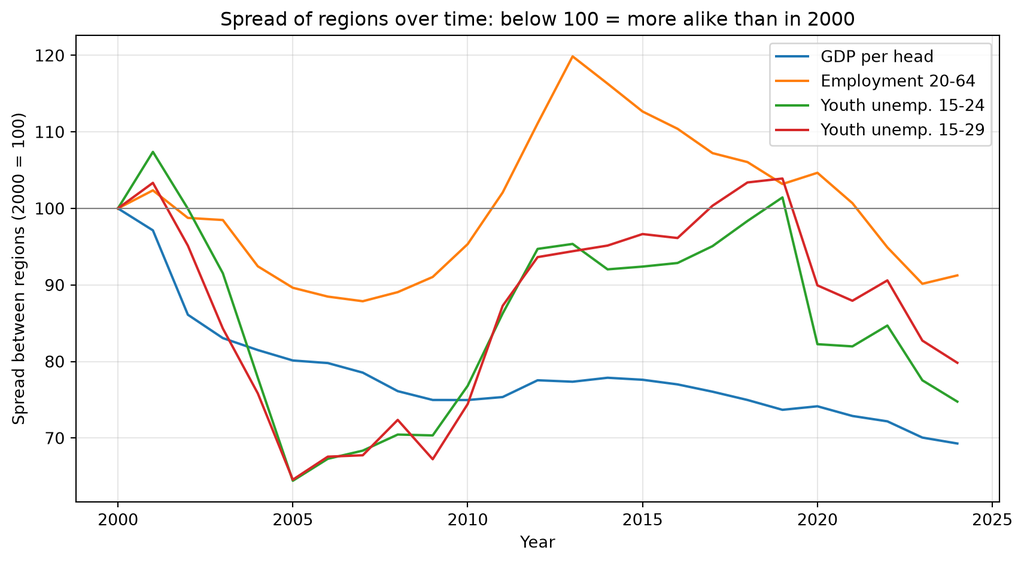

Figure 5: Spread between regions over time, 2000 = 100. A value below 100 means the regions are more alike than in 2000.

```python
fig, ax = plt.subplots(figsize=(9, 5))
for name, w in [("GDP per head", gdp), ("Employment 20-64", emp),
                ("Youth unemp. 15-24", w24), ("Youth unemp. 15-29", w29)]:
    s = np.log(w).std()
    ax.plot(s.index, s / s[2000] * 100, label=name)
ax.axhline(100, color="grey", linewidth=0.8)
ax.set_xlabel("Year")
ax.set_ylabel("Spread between regions (2000 = 100)")
ax.set_title("Spread of regions over time: below 100 = more alike than in 2000")
ax.legend()
ax.grid(alpha=0.3)
fig.tight_layout()
plt.show()
```

Over the whole period 2000-2024 the two tests agree for all four indicators: the spread is smaller and the slope is negative (Table 17). The GDP rows use the 232 regions that have GDP in both 2000 and 2024, so the change in the spread (-32.0%) differs from Question 1, which gives -31% (all regions available each year) and -26% (the 224 regions with every year). In the crisis (2008-2013) they also agree, on bad news: for employment and for youth unemployment the spread grows by about a third and the slope turns positive, so the regions became less alike (Figure 5). They disagree after 2008. For youth unemployment in 2008-2024 the spread does not fall (+1.9% for ages 15-24, +6.2% for ages 15-29), while the slope is still negative (-0.15 for both), although the R-squared is only 0.05. For employment in 2008-2024 the spread is almost unchanged (-4.5%) while the slope is clearly negative (-0.19). For GDP in 2008-2013 the spread is flat (-1.6%) and the slope only slightly negative, a small difference.

```python
# regions that do not follow the catching-up pattern (ages 15-24)
d24["predicted"] = m24.intercept + m24.slope * d24[2000]
d24["gap"] = d24["change"] - d24["predicted"]
print(d24.sort_values("gap", ascending=False).head(8)[[2000, 2024, "change", "predicted", "gap"]].round(1))
print("Regions where youth unemployment (15-24) went UP:", int((d24["change"] > 0).sum()), "of", len(d24))
print(d24.sort_values("gap").head(5)[[2000, 2024, "change", "predicted", "gap"]].round(1))
```

```
year  2000  2024  change  predicted   gap
geo
ES63  46.5  66.5    20.0      -14.8  34.8
RO22  20.1  34.8    14.7       -1.6  16.3
RO41  14.0  30.6    16.6        1.4  15.2
ES23  19.1  31.7    12.6       -1.1  13.7
RO31  21.4  30.6     9.2       -2.3  11.5
ES42  19.6  29.0     9.4       -1.4  10.8
ES61  36.4  36.9     0.5       -9.8  10.3
SE22  15.4  26.3    10.9        0.7  10.2
Regions where youth unemployment (15-24) went UP: 56 of 123
year  2000  2024  change  predicted   gap
geo
PL51  42.1  11.5   -30.6      -12.6 -18.0
PL22  34.1   9.3   -24.8       -8.6 -16.2
CZ08  30.5  11.0   -19.5       -6.8 -12.7
PL21  27.6   9.7   -17.9       -5.4 -12.5
SK03  37.5  16.1   -21.4      -10.3 -11.1
```

The reason is that the catching-up test only asks whether the regions that started worse improved more. It does not ask whether other regions fell behind. In 56 of the 123 regions youth unemployment (ages 15-24) was higher in 2024 than in 2000. The regions that did worst compared with the pattern are mostly Spanish and Romanian (for example ES23, ES42, RO22, RO41, RO31; ES63 is the small city of Ceuta, where numbers are noisy), while Polish, Czech and Slovak regions (PL51, PL22, CZ08, PL21, SK03) fell much more than the pattern predicts. This means that regions that started high, such as southern Italy, Poland and Slovakia, fell the most, but other regions moved the wrong way, so the overall spread did not shrink after 2008.

### Which test do we believe?

For the question “is the gap closing?” we believe the spread test more, because it measures the gap directly. The catching-up test shows who improved, but it cannot show that the gap closed. For youth unemployment we read both tests with care. The spread line jumps for data reasons (the break in 2005 and the missing German regions from 2020) and depends on the end year: in 2019 it was back at its 2000 level. The catching-up slope is probably too strong, because the starting values are noisy (about 20% of the 15-24 values are flagged as low reliability) and a region whose rate in 2000 was too high by chance looks like it improved a lot; we did not test this. We trust a result most when the tests, the two age groups and the sub-periods agree, as for GDP. For youth unemployment after 2008 the tests disagree, so we cannot say that regions became more alike.

### Limitations of this analysis

- Only 123 of 248 regions (ages 15-24) and 151 of 251 regions (ages 15-29) have a value in both 2000 and 2024, so the catching-up test covers about half of the regions.
- About 20% of the 15-24 values are flagged as low reliability.
- The set of regions changes from year to year and there are breaks in the series (2005 and 2021). From 2020 the German regions have no values, so the spread line jumps for reasons that are not about the regions.
- The result depends on the start year and the end year (2019 against 2024).
- The catching-up slope may be too strong because of noisy starting values (not tested).
- We did not test whether the slopes for ages 15-24 and 15-29 differ significantly.
- The sub-periods (2008 and 2013) are our own choice, and other cut points could give slightly different numbers.

## Conclusion and limitations

**Answer to our question.** Yes, EU27 regions converged between 2000 and 2024, but how clearly depends on the indicator and on the period.

- **Income (GDP per head, PPS).** The spread across regions fell by about 31% (all regions available each year) and 26% (the 224 regions with every year), and poorer regions grew faster: the poorest quarter grew by 5.2% a year, the richest quarter by 2.8% (slope -0.0199, R-squared 0.55). About 60% of the fall in the spread came before 2008.
- **Employment (ages 20-64).** Regions with a lower starting rate gained more (slope -0.34, R-squared 0.20). The spread fell by 16% over the whole period, but in the crisis (2008-2013) it grew by about a third.
- **Youth unemployment (ages 15-24).** Regions with high starting rates improved most (slope -0.50), but the spread was back at its 2000 level in 2019, so we cannot say that the gap closed.
- **Which regions did not follow.** In youth unemployment, 56 of 123 regions had a higher rate in 2024 than in 2000, mostly Spanish and Romanian regions, while Polish, Czech and Slovak regions improved much more than expected. In the sector groups, the spread of income inside the public services group (mostly French, German and Italian regions) rose from 0.14 to 0.20, while it fell in the other groups.
- **Structure or geography.** Regions fall into five loose types of economy by their sector mix in 2000. The types are partly national (agreement with the countries 0.11) and add only about half a percentage point to explaining growth once the country and the starting income are known.
- **The two tests.** Over the whole period the spread test and the catching-up test agree for all four indicators. After 2008 they disagree for employment and youth unemployment: the slope stays negative while the spread does not fall. For the question “is the gap closing?” we believe the spread test more, because it measures the gap directly.

**Limitations of the whole project.**

- **Data gaps.** Only 224 of 244 regions have a GDP value in every year. Only 199 regions have an employment rate and 123 a youth unemployment rate in both 2000 and 2024, so the tests do not always cover the same regions.
- **Region codes.** Renamed regions were joined to their new codes, but regions that were split or merged (Hungary, Lithuania, Croatia, Ireland, Portugal) were not, so they have gaps.
- **Association, not cause.** We describe how regions changed. We do not show why, for example whether EU funding played a role.
- **Our choices.** PPS as the income measure, ages 20-64 and 15-24, the ten big city regions in the commuter check, the sub-periods 2008 and 2013 and five groups in Question 3 are our own choices. Where we tested other choices, the main result did not change; where we did not, we said so in each section.
- **Data quality.** Values for 2023 and 2024 are provisional or estimated, and some series have breaks that Eurostat flags (employment in 2024, youth unemployment in 2005).

## Use of AI

See `AI_Usage.md` for the prompts, the model and its settings, and the computational effort.